# Nienadzorowana Detekcja Fraudów Bankowych

## 2.3 Profil fraudow — zmienne kategoryczne

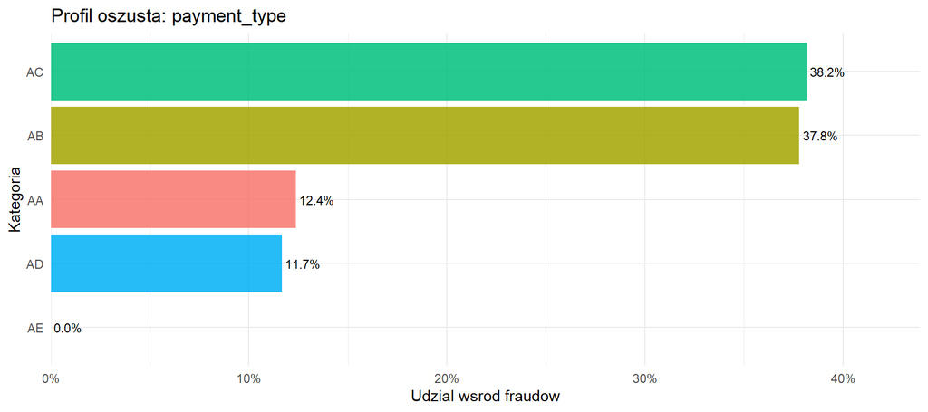

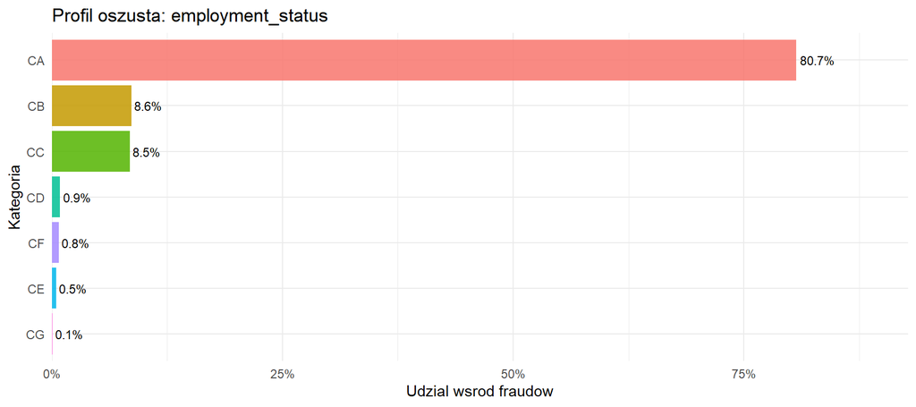

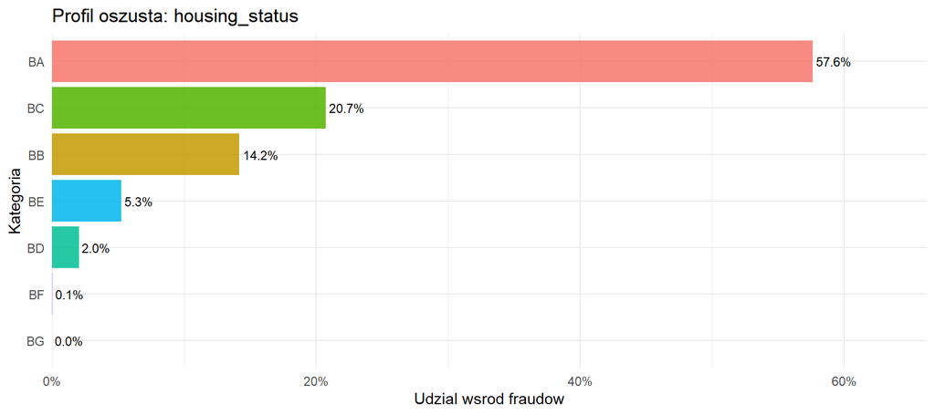

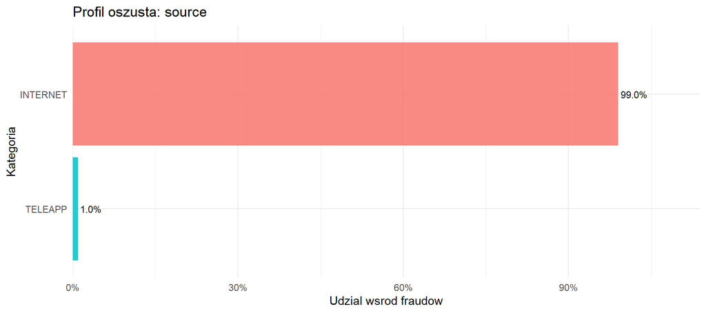

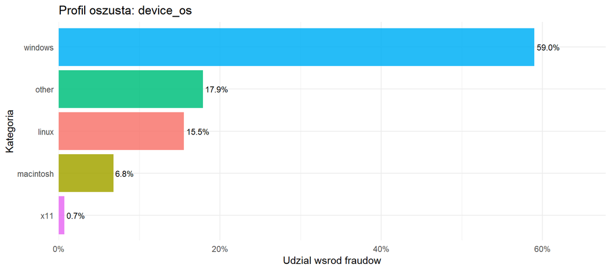

```r
cat_features  <- c("payment_type","employment_status","housing_status","source","device_os")
df_frauds_eda <- df_clean %>% filter(fraud_bool == "Fraud")
for (feat in cat_features) {
  pd <- df_frauds_eda %>% count(!!sym(feat)) %>% mutate(pct = n / sum(n))
  p  <- ggplot(pd, aes(reorder(!!sym(feat), pct), pct, fill = !!sym(feat))) +
    geom_col(show.legend = FALSE, alpha = 0.85) +
    geom_text(aes(label = percent(pct, accuracy = 0.1)), hjust = -0.1, size = 3) +
    coord_flip() +
    scale_y_continuous(labels = percent, expand = expansion(mult = c(0, 0.15))) +
    labs(title = paste("Profil oszusta:", feat),
         x = "Kategoria", y = "Udzial wsrod fraudow") + theme_minimal()
  print(p)
}
```

```r
rm(df_frauds_eda, pd, p, cat_features, feat)
```

## 2.4 Macierz korelacji Spearmana

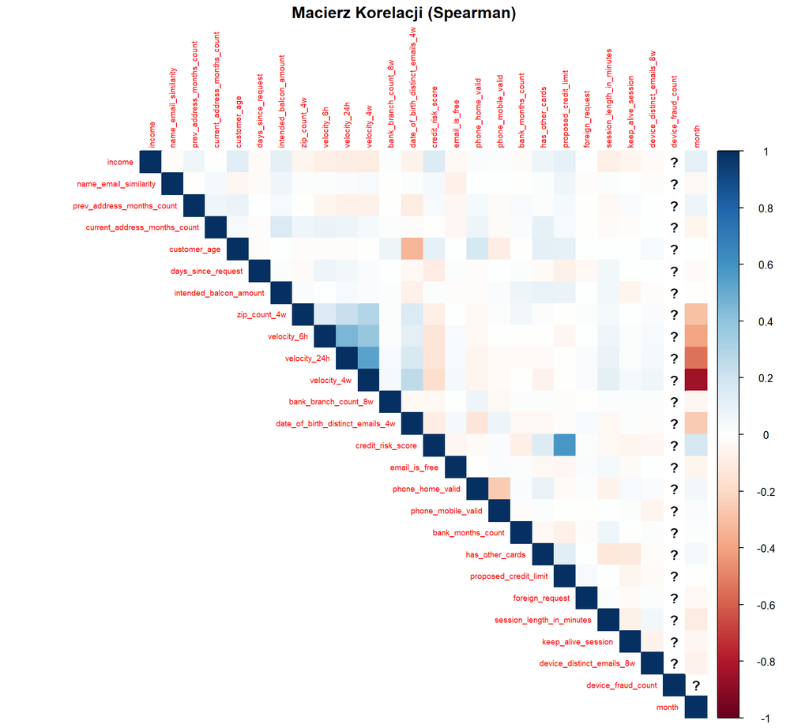

```r
numeric_df <- df_clean %>% select(where(is.numeric)) %>% drop_na()
corrplot(cor(numeric_df, method = "spearman"),
         method = "color", type = "upper", tl.cex = 0.6,
         title = "Macierz Korelacji (Spearman)", mar = c(0,0,1.5,0))
```

```r
rm(numeric_df)
```

## 2.5 Skosnosc rozkladow zmiennych numerycznych

```r
numeric_vars <- c("income","customer_age","name_email_similarity",
                  "credit_risk_score","current_address_months_count",
                  "velocity_6h","velocity_24h","velocity_4w","zip_count_4w",
                  "days_since_request","intended_balcon_amount",
                  "bank_months_count","proposed_credit_limit")

skew_vals <- sapply(numeric_vars,
                    function(v) round(e1071::skewness(df_clean[[v]], na.rm=TRUE), 3))

tibble(Zmienna = numeric_vars, Skosnosc = skew_vals,
       Transformacja = ifelse(abs(skew_vals) > 1, "Yeo-Johnson", "Brak")) %>%
  kable(caption = "Skosnosc zmiennych numerycznych i decyzja o transformacji") %>%
  kable_styling(bootstrap_options = c("striped","hover","condensed"), full_width = FALSE)
```

Skosnosc zmiennych numerycznych i decyzja o transformacji

| Zmienna | Skosnosc | Transformacja |
| --- | --- | --- |
| income | -0.386 | Brak |
| customer_age | 0.478 | Brak |
| name_email_similarity | 0.043 | Brak |
| credit_risk_score | 0.296 | Brak |
| current_address_months_count | 1.384 | Yeo-Johnson |
| velocity_6h | 0.563 | Brak |
| velocity_24h | 0.331 | Brak |
| velocity_4w | -0.060 | Brak |
| zip_count_4w | 1.457 | Yeo-Johnson |
| days_since_request | 9.279 | Yeo-Johnson |
| intended_balcon_amount | 2.507 | Yeo-Johnson |
| bank_months_count | 0.039 | Brak |
| proposed_credit_limit | 1.301 | Yeo-Johnson |

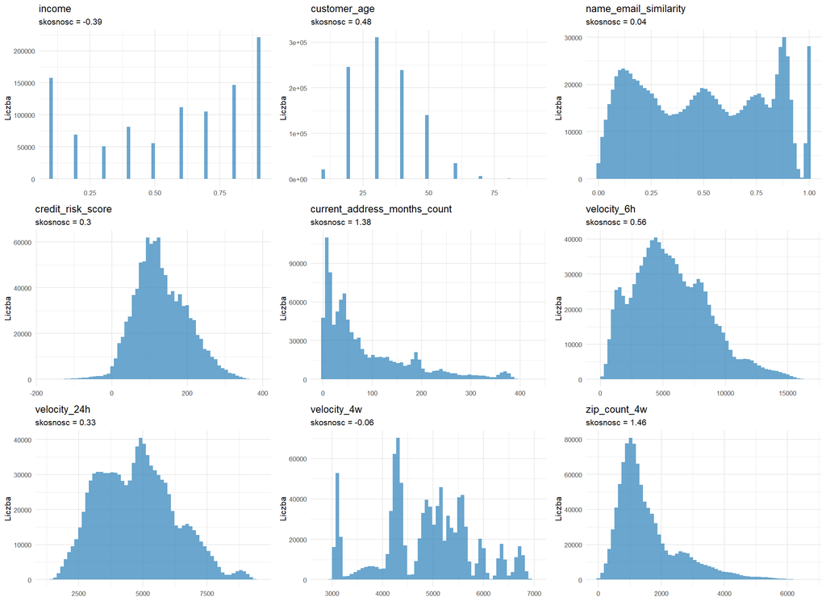

```r
plots <- lapply(numeric_vars[1:9], function(v) {
  sk <- round(e1071::skewness(df_clean[[v]], na.rm = TRUE), 2)
  ggplot(df_clean, aes(.data[[v]])) +
    geom_histogram(bins = 60, fill = "#2980b9", alpha = 0.7) +
    labs(title = v, subtitle = paste("skosnosc =", sk), x = NULL, y = "Liczba") +
    theme_minimal(base_size = 8)
})
do.call(grid.arrange, c(plots, ncol = 3))
```

```r
rm(plots, skew_vals)
```

**Decyzja:** Transformacja Yeo-Johnsona jest stosowana dla zmiennych z |skosnosc| > 1. Jest preferowana nad transformacja logarytmiczna poniewaz: (1) obsluguje zera i wartosci ujemne, (2) parametry sa estymowane na zbiorze treningowym i aplikowane na testowym, co zapobiega wyciekowi danych, **Wazne zastrzezenie:** transformacja kompresuje wartosci ogonowe ku sredniej, co moze tlumiac sygnal anomalii.

# 3 Podział Czasowy (Temporal Split)

```r
# Kluczowa decyzja metodologiczna: podział CZASOWY zamiast losowego 80/20.
#
# Uzasadnienie (Jesus et al. 2022, Section 3.2):
# Zbior BAF zawiera celowo wbudowany concept drift miedzy miesiacami 0-5 a 6-7.
# Podział losowy pozwalałby modelowi "widziec" wzorce fraudow z tych samych
# okien czasowych co zbior testowy — co zawyza AUC i nie odzwierciedla
# realistycznego scenariusza produkcyjnego.
#
# W produkcyjnym systemie detekcji fraudow model zawsze trenowany jest na
# danych historycznych i oceniany na przyszlych, nieznanych transakcjach.
# Podział czasowy symuluje te realia.

df_clean <- df_clean %>% mutate(.row_id = row_number())
df_train_raw <- df_clean %>% filter(month <= 5)
df_test_raw  <- df_clean %>% filter(month >= 6)

cat("=== Podział czasowy ===\n")
```

```
## === Podział czasowy ===
```

```r
cat("Trening (miesiace 0-5):", nrow(df_train_raw), "obserwacji\n")
```

```
## Trening (miesiace 0-5): 794989 obserwacji
```

```r
cat("Test    (miesiace 6-7):", nrow(df_test_raw),  "obserwacji\n")
```

```
## Test    (miesiace 6-7): 205011 obserwacji
```

```r
cat("Udzial fraudow w treningu:", round(mean(df_train_raw$fraud_bool=="Fraud")*100, 2), "%\n")
```

```
## Udzial fraudow w treningu: 1.03 %
```

```r
cat("Udzial fraudow w tescie: ", round(mean(df_test_raw$fraud_bool=="Fraud")*100,  2), "%\n")
```

```
## Udzial fraudow w tescie:  1.4 %
```

```r
cat("Fraudow w zbiorze testowym:", sum(df_test_raw$fraud_bool=="Fraud"), "\n")
```

```
## Fraudow w zbiorze testowym: 2878
```

**Obserwacja concept drift:** Udzial fraudow wzrosl z 1.03% (trening) do 1.40% (test), czyli o 36%.To systematyczna zmiana wzorcow fraudowych w czasie, celowo zaprojektowana w zbiorze BAF jako test odpornosci modeli na realistyczne warunki produkcyjne.

# 4 Inzynieria Cech

Wszystkie operacje inzynieryjne sa wykonywane po podziale i przed recepturami preprocessing, aby zapobiec wyciekowi danych.

## 4.1 Flagi brakow danych (Missingness Indicators)

```r
# Braki danych w zbiorze BAF nie sa losowe (MNAR — Missing Not At Random).
# Wnioskodawcy z fraudulentnym zamiarem czesciej nie podaja historii adresowej,
# co skutkuje wysokim odsetkiem NA w prev_address_months_count (71.3%).
# Zamiana brakow na mediane (imputacja) NISZCZY ten sygnal.
# Rozwiazanie: tworzymy binarne flagi 0/1 PRZED imputacja, zachowujac informacje.

add_missingness_flags <- function(df, cols) {
  for (col in cols) df[[paste0("na_flag_", col)]] <- as.integer(is.na(df[[col]]))
  df
}

df_train_raw <- add_missingness_flags(df_train_raw, cols_with_missing)
df_test_raw  <- add_missingness_flags(df_test_raw,  cols_with_missing)
df_clean     <- add_missingness_flags(df_clean,     cols_with_missing)

cat("Dodano flag brakow danych:", length(cols_with_missing), "\n")
```

```
## Dodano flag brakow danych: 6
```

```r
cat("\nSredni odsetek NA wsrod fraudow (zbior treningowy):\n")
```

```
##
## Sredni odsetek NA wsrod fraudow (zbior treningowy):
```

```r
df_train_raw %>% filter(fraud_bool == "Fraud") %>%
  summarise(across(starts_with("na_flag_"), mean, na.rm = TRUE)) %>%
  pivot_longer(everything(), names_to = "Flaga", values_to = "Srednia") %>%
  mutate(Flaga = str_remove(Flaga, "na_flag_")) %>%
  kable(digits = 3) %>%
  kable_styling(bootstrap_options = c("striped","condensed"), full_width = FALSE)
```

| Flaga | Srednia |
| --- | --- |
| prev_address_months_count | 0.922 |
| current_address_months_count | 0.001 |
| intended_balcon_amount | 0.000 |
| bank_months_count | 0.376 |
| session_length_in_minutes | 0.002 |
| device_distinct_emails_8w | 0.000 |

**Obserwacja:** `prev_address_months_count` brakuje dla **92.2%** fraudow w treningu. To jest najsilniejszy jednowymiarowy sygnal w zbiorze — osby klasyfikowane jako anomalie systematycznie nie podaja historii adresowej. Flaga `na_flag_prev_address_months_count` jest prawie-etykietą o nieco innym charakterze niz `device_fraud_count` (dotyczy zachowania wnioskodawcy, nie historii urzadzenia).

## 4.2 Kodowanie czestotliwoscia kategorii (Frequency Encoding)

```r
# Frequency encoding zastepuje kategorie ich empiryczna czestotliwoscia w zbiorze
# TRENINGOWYM. Kluczowe zalety nad one-hot encoding dla modeli dystansowych:
# 1. x11 (0.7% przypadkow) staje sie liczba 0.007 — rzadkosc jest wprost widoczna
# 2. Nie tworzy dodatkowych kolumn binarnych, ktore znieksztalcaja odleglosc
# 3. Nowe kategorie w zbiorze testowym dostaja wartosc min(czestotliwosci_treningowe)
#    zamiast 0 (ktore tworzyloby falszywy sygnal anomalii)
#
# UWAGA: Czestotliwosci MUSZA byc obliczane tylko na treningu.
# Obliczanie na pelnym zbiorze to Data Leakage (przeciek informacji testowej).

freq_device_os_tbl <- df_train_raw %>% count(device_os) %>%
  mutate(freq_device_os = n / sum(n)) %>% select(device_os, freq_device_os)
freq_source_tbl <- df_train_raw %>% count(source) %>%
  mutate(freq_source = n / sum(n)) %>% select(source, freq_source)

fallback_os  <- min(freq_device_os_tbl$freq_device_os)
fallback_src <- min(freq_source_tbl$freq_source)

apply_freq_enc <- function(df) {
  df %>%
    left_join(freq_device_os_tbl, by = "device_os") %>%
    left_join(freq_source_tbl,    by = "source") %>%
    mutate(freq_device_os = replace_na(freq_device_os, fallback_os),
           freq_source    = replace_na(freq_source,    fallback_src))
}

df_train_raw <- apply_freq_enc(df_train_raw)
df_test_raw  <- apply_freq_enc(df_test_raw)
df_clean     <- apply_freq_enc(df_clean)

cat("Rozklad czestotliwosci device_os (rozklad treningowy):\n")
```

```
## Rozklad czestotliwosci device_os (rozklad treningowy):
```

```r
freq_device_os_tbl %>% arrange(freq_device_os) %>%
  kable(digits = 4, caption = "Frequency encoding device_os") %>%
  kable_styling(bootstrap_options = c("striped","condensed"), full_width = FALSE)
```

Frequency encoding device_os

| device_os | freq_device_os |
| --- | --- |
| x11 | 0.0075 |
| macintosh | 0.0541 |
| windows | 0.2678 |
| other | 0.3339 |
| linux | 0.3367 |

```r
rm(freq_device_os_tbl, freq_source_tbl, fallback_os, fallback_src)
```

## 4.3 Cechy ratio (inzynieria relacji miedzy zmiennymi)

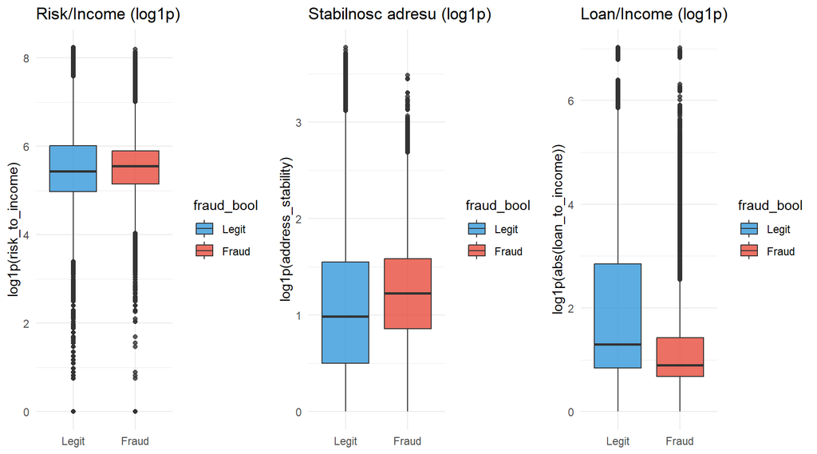

```r
# Cechy ratio eksponuja zaleznosci miedzy zmiennymi, ktore sa niewidoczne
# dla modeli operujacych na surowych cechach z osobna.
# KLUCZOWE: komponenty sa imputowane medianami ZE ZBIORU TRENINGOWEGO
# przed dzieleniem, aby zapobiec propagacji NA do nowych cech.

med_income <- median(df_train_raw$income,                       na.rm = TRUE)
med_age    <- median(df_train_raw$customer_age,                 na.rm = TRUE)
med_addr   <- median(df_train_raw$current_address_months_count, na.rm = TRUE)
med_balcon <- median(df_train_raw$intended_balcon_amount,       na.rm = TRUE)
med_risk   <- median(df_train_raw$credit_risk_score,            na.rm = TRUE)

add_ratio_features <- function(df) {
  df %>% mutate(
    inc_imp    = if_else(is.na(income), med_income, income),
    age_imp    = if_else(is.na(customer_age), med_age, customer_age),
    addr_imp   = if_else(is.na(current_address_months_count), med_addr, current_address_months_count),
    balcon_imp = if_else(is.na(intended_balcon_amount), med_balcon, intended_balcon_amount),
    risk_imp   = if_else(is.na(credit_risk_score), med_risk, credit_risk_score),
    # Ryzyko nieproporcjonalne do dochodu — sygnal Synthetic Identity Fraud
    risk_to_income    = risk_imp  / (inc_imp    + 1e-6),
    # Stabilnosc adresowa wzgledem wieku — 60-latek na 1-miesacznym adresie jest anomalny
    address_stability = addr_imp  / (age_imp    + 1e-6),
    # Loan-to-income — bust-out fraud: maksymalizacja limitu wzgledem dochodu
    loan_to_income    = balcon_imp / (inc_imp   + 1e-6)
  ) %>% select(-inc_imp, -age_imp, -addr_imp, -balcon_imp, -risk_imp)
}

df_train_raw <- add_ratio_features(df_train_raw)
df_test_raw  <- add_ratio_features(df_test_raw)
df_clean     <- add_ratio_features(df_clean)
rm(med_income, med_age, med_addr, med_balcon, med_risk)

# Wizualizacja
p1 <- ggplot(df_clean, aes(fraud_bool, log1p(risk_to_income), fill = fraud_bool)) +
  geom_boxplot(alpha=0.8) + scale_fill_manual(values=c("#3498db","#e74c3c")) +
  theme_minimal() + labs(title="Risk/Income (log1p)", x=NULL)
p2 <- ggplot(df_clean, aes(fraud_bool, log1p(address_stability), fill=fraud_bool)) +
  geom_boxplot(alpha=0.8) + scale_fill_manual(values=c("#3498db","#e74c3c")) +
  theme_minimal() + labs(title="Stabilnosc adresu (log1p)", x=NULL)
p3 <- ggplot(df_clean, aes(fraud_bool, log1p(abs(loan_to_income)), fill=fraud_bool)) +
  geom_boxplot(alpha=0.8) + scale_fill_manual(values=c("#3498db","#e74c3c")) +
  theme_minimal() + labs(title="Loan/Income (log1p)", x=NULL)
grid.arrange(p1, p2, p3, ncol=3)
```

```r
rm(p1, p2, p3)
```

# 5 Dobor Zestawu Cech

## 5.1 Iteracyjne testy zestawow cech

Zamiast arbitralnie dobierac cechy, porownujemy 5 zestawow w kontrolowanym eksperymencie out-of-sample. Kazdy zestaw oceniamy na trzech modelach, co pozwala zrozumiec jak dodawanie cech wplywa na rozne klasy algorytmow.

```r
test_feature_set <- function(features, set_name) {
  cat("Testuje:", set_name, "...\n")
  tmp_rec <- recipe(fraud_bool ~ .,
                    data = df_train_raw %>% select(all_of(features), fraud_bool)) %>%
    step_impute_median(all_numeric_predictors()) %>%
    step_dummy(all_nominal_predictors()) %>%
    step_zv(all_predictors()) %>%
    step_YeoJohnson(all_numeric_predictors()) %>%
    step_corr(all_numeric_predictors(), threshold = 0.85) %>%
    step_normalize(all_numeric_predictors()) %>%
    prep()

  tr <- bake(tmp_rec, new_data = NULL)    %>% select(-fraud_bool)
  te <- bake(tmp_rec, new_data = df_test_raw) %>% select(-fraud_bool)

  auc_mahala <- tryCatch({
    mu <- colMeans(tr); S <- cov(tr)
    as.numeric(auc(roc(y_test, as.numeric(mahalanobis(te, mu, S)), quiet=TRUE)))
  }, error = function(e) NA_real_)

  auc_iof <- tryCatch({
    m <- isolation.forest(tr, ntrees=100, sample_size=256)
    as.numeric(auc(roc(y_test, predict(m, te), quiet=TRUE)))
  }, error = function(e) NA_real_)

  auc_lof <- tryCatch({
    tr_noa <- tr %>% select(-any_of("customer_age"))
    te_noa <- te %>% select(-any_of("customer_age"))
    ref <- as.matrix(tr_noa[sample(nrow(tr_noa), min(5000,nrow(tr_noa))),])
    knn_r <- dbscan::kNN(x=ref, query=as.matrix(te_noa), k=20)
    as.numeric(auc(roc(y_test, rowMeans(knn_r$dist), quiet=TRUE)))
  }, error = function(e) NA_real_)

  rm(tmp_rec, tr, te); gc(verbose=FALSE)
  tibble(Zestaw=set_name, n_cech=length(features), AUC_Mahala=auc_mahala,
         AUC_iForest=auc_iof, AUC_LOF=auc_lof)
}

y_test <- ifelse(df_test_raw$fraud_bool == "Fraud", 1, 0)

base_features <- c(
  "income","customer_age","name_email_similarity","credit_risk_score",
  "current_address_months_count","device_os",
  "velocity_6h","velocity_24h","velocity_4w","zip_count_4w",
  "email_is_free","phone_mobile_valid","foreign_request",
  "days_since_request","intended_balcon_amount","bank_months_count",
  "proposed_credit_limit","date_of_birth_distinct_emails_4w",
  "device_distinct_emails_8w","bank_branch_count_8w","has_other_cards"
)
```

```r
feature_sets <- list(
  "Minimalistyczny"  = c("income","customer_age"),
  "Full_Base"        = c("income","customer_age","name_email_similarity",
                         "credit_risk_score","device_os"),
  "Full_Velocity"    = c("income","customer_age","name_email_similarity",
                         "credit_risk_score","device_os",
                         "velocity_6h","velocity_24h","velocity_4w","zip_count_4w"),
  "Sygnaly_binarne"  = c("income","customer_age","name_email_similarity",
                         "credit_risk_score","device_os",
                         "email_is_free","phone_mobile_valid","foreign_request"),
  "Full_Extended"    = base_features
)

feature_results <- map2_df(feature_sets, names(feature_sets), test_feature_set)
```

```
## Testuje: Minimalistyczny ...
## Testuje: Full_Base ...
## Testuje: Full_Velocity ...
## Testuje: Sygnaly_binarne ...
## Testuje: Full_Extended ...
```

```r
feature_results %>%
  kable(digits=3, caption="AUC-ROC wedlug zestawu cech i modelu (out-of-sample)") %>%
  kable_styling(bootstrap_options=c("striped","hover","condensed"), full_width=FALSE)
```

AUC-ROC wedlug zestawu cech i modelu (out-of-sample)

| Zestaw | n_cech | AUC_Mahala | AUC_iForest | AUC_LOF |
| --- | --- | --- | --- | --- |
| Minimalistyczny | 2 | 0.576 | 0.549 | 0.500 |
| Full_Base | 5 | 0.664 | 0.674 | 0.591 |
| Full_Velocity | 9 | 0.572 | 0.618 | 0.560 |
| Sygnaly_binarne | 8 | 0.649 | 0.659 | 0.606 |
| Full_Extended | 21 | 0.572 | 0.591 | 0.565 |

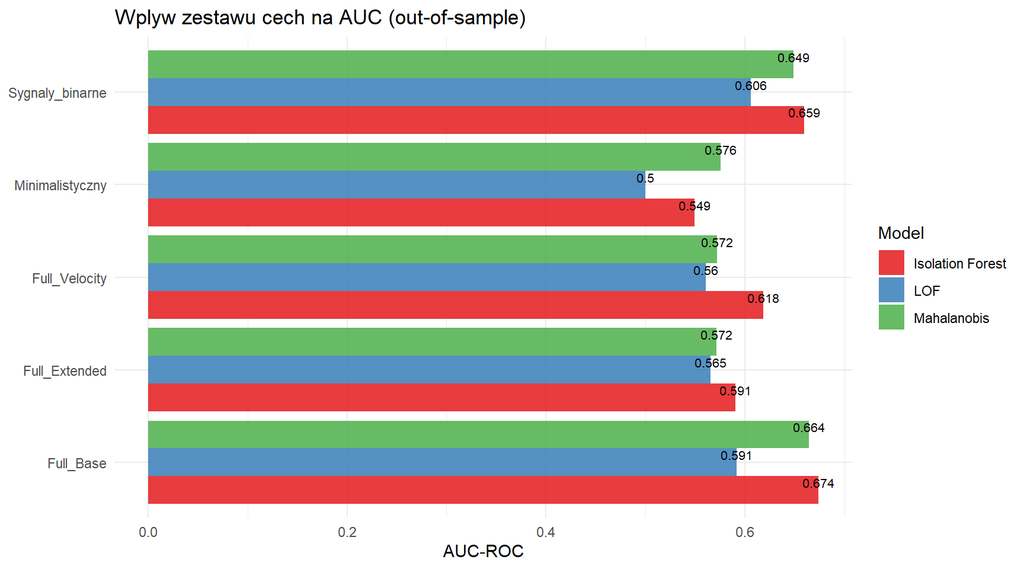

```r
feature_results %>%
  pivot_longer(starts_with("AUC"), names_to="Model", values_to="AUC") %>%
  mutate(Model = recode(Model, AUC_Mahala="Mahalanobis",
                        AUC_iForest="Isolation Forest", AUC_LOF="LOF")) %>%
  ggplot(aes(Zestaw, AUC, fill=Model)) +
  geom_col(position="dodge", alpha=0.85) +
  geom_text(aes(label=round(AUC,3)), position=position_dodge(0.9),
            vjust=-0.3, size=2.8, na.rm=TRUE) +
  coord_flip() + theme_minimal() + scale_fill_brewer(palette="Set1") +
  labs(title="Wplyw zestawu cech na AUC (out-of-sample)",
       x=NULL, y="AUC-ROC", fill="Model")
```